# CSSA single-line stress cases

Alex

2026-03-06

## Конфигурации

```r
sigma_noise <- 0.2
n_repeats <- 16
num_of_lines <- 1L

configs <- data.frame(
  config_id = c(
    "diag_pos_full",
    "diag_neg_full",
    "shallow_bottom",
    "shallow_center",
    "steep_full",
    "steep_shifted",
    "short_corner",
    "horizontal",
    "almost_horizontal"
  ),
  n_col = rep(100L, 9),
  n_row = rep(100L, 9),
  a = c(1, -1, 0.5, 0.5, 2, 2, 1, 0, 0.05),
  b = c(0, 101, 0, 25, -1, -40, 70, 20, 30),
  description = c(
    "Positive full diagonal",
    "Negative full diagonal",
    "Shallow line from lower border",
    "Shallow central line",
    "Steep line crossing most of the image",
    "Steep shifted line with shorter visible segment",
    "Short corner segment",
    "Horizontal",
    "Almost Horizontal"
  ),
  stringsAsFactors = FALSE
)

configs
```

```
##           config_id n_col n_row     a   b
## 1     diag_pos_full   100   100  1.00   0
## 2     diag_neg_full   100   100 -1.00 101
## 3    shallow_bottom   100   100  0.50   0
## 4    shallow_center   100   100  0.50  25
## 5        steep_full   100   100  2.00  -1
## 6     steep_shifted   100   100  2.00 -40
## 7      short_corner   100   100  1.00  70
## 8        horizontal   100   100  0.00  20
## 9 almost_horizontal   100   100  0.05  30
##                                       description
## 1                          Positive full diagonal
## 2                          Negative full diagonal
## 3                  Shallow line from lower border
## 4                            Shallow central line
## 5           Steep line crossing most of the image
## 6 Steep shifted line with shorter visible segment
## 7                            Short corner segment
## 8                                      Horizontal
## 9                               Almost Horizontal
```

Вот так выглядят прямые с такими параметрами

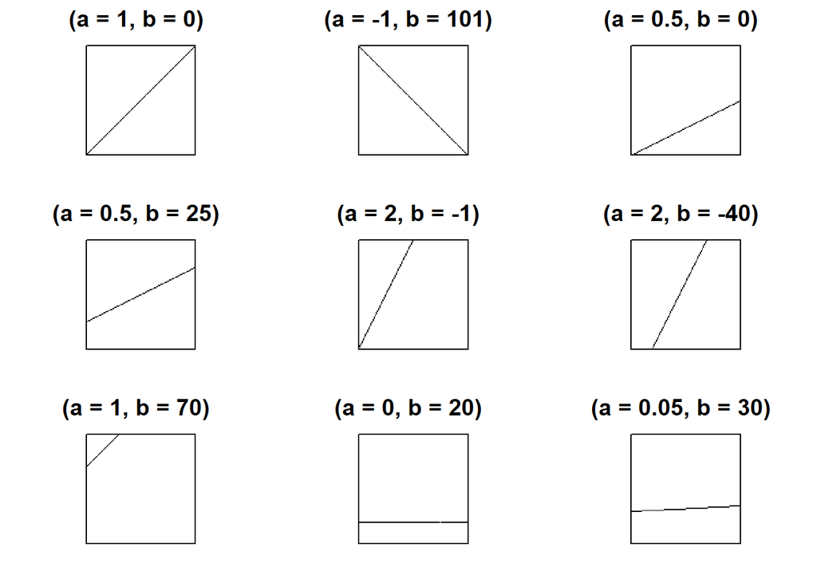

```r
config_matrices <- lapply(seq_len(nrow(configs)), function(i) {
  matrix(0, nrow = configs$n_row[i], ncol = configs$n_col[i]) |>
    add.line(a = configs$a[i], b = configs$b[i])
})

config_labels <- sprintf("(a = %s, b = %s)", configs$a, configs$b)

plot.matrix(
  config_matrices,
  from.0.to.1 = TRUE,
  labels = config_labels,
  nplots = 3
)
```

## Вспомогательные функции

```r
clip01 <- function(m) {
  m <- as.matrix(m)
  m[m < 0.001] <- 0
  m[m > 0.999] <- 1
  m
}

mse <- function(truth, pred) {
  mean((truth - pred)^2)
}

cssa_denoise <- function(m, num_of_lines = 1L, method = "row.row") {
  cleaned <- switch(
    method,
    "col.col" = m |> dft() |> cssa.col(num.line = num_of_lines) |> idft.col() |> Re(),
    "col.row" = m |> dft() |> cssa.col(num.line = num_of_lines) |> idft.row() |> Re(),
    "row.col" = m |> dft() |> cssa.row(num.line = num_of_lines) |> idft.col() |> Re(),
    "row.row" = m |> dft() |> cssa.row(num.line = num_of_lines) |> idft.row() |> Re(),
    stop("Unknown method: ", method)
  )
  clip01(cleaned)
}

line_coverage_stats <- function(m) {
  idx <- which(m > 0, arr.ind = TRUE)
  if (nrow(idx) == 0) {
    return(c(
      visible_pixels = 0,
      row_coverage = 0,
      col_coverage = 0
    ))
  }

  c(
    visible_pixels = nrow(idx),
    row_coverage = length(unique(idx[, 1])) / nrow(m),
    col_coverage = length(unique(idx[, 2])) / ncol(m)
  )
}

make_line_image <- function(n_row, n_col, a, b) {
  matrix(0, nrow = n_row, ncol = n_col) |>
    add.line(a = a, b = b)
}
```

## Эксперимент с MSE

```r
methods_cssa <- c("row.row", "col.row", "row.col", "col.col")

results_list <- vector("list", length = nrow(configs) * n_repeats * length(methods_cssa))
idx_out <- 1L

for (cfg_i in seq_len(nrow(configs))) {
  cfg <- configs[cfg_i, ]
  base_matrix <- make_line_image(
    n_row = cfg$n_row,
    n_col = cfg$n_col,
    a = cfg$a,
    b = cfg$b
  )
  coverage <- line_coverage_stats(base_matrix)

  for (rep_i in seq_len(n_repeats)) {
    noisy_matrix <- add.noise(base_matrix, sigma = sigma_noise)

    for (method_name in methods_cssa) {
      denoised <- cssa_denoise(
        noisy_matrix,
        num_of_lines = num_of_lines,
        method = method_name
      )

      results_list[[idx_out]] <- data.frame(
        config_id = cfg$config_id,
        description = cfg$description,
        n_col = cfg$n_col,
        n_row = cfg$n_row,
        a = cfg$a,
        b = cfg$b,
        visible_pixels = unname(coverage["visible_pixels"]),
        row_coverage = unname(coverage["row_coverage"]),
        col_coverage = unname(coverage["col_coverage"]),
        sigma = sigma_noise,
        rep = rep_i,
        method = method_name,
        mse = mse(base_matrix, denoised),
        stringsAsFactors = FALSE
      )
      idx_out <- idx_out + 1L
    }
  }
}

error_samples <- do.call(rbind, results_list)
head(error_samples, 12)
```

```
##        config_id            description n_col n_row a b visible_pixels
## 1  diag_pos_full Positive full diagonal   100   100 1 0            100
## 2  diag_pos_full Positive full diagonal   100   100 1 0            100
## 3  diag_pos_full Positive full diagonal   100   100 1 0            100
## 4  diag_pos_full Positive full diagonal   100   100 1 0            100
## 5  diag_pos_full Positive full diagonal   100   100 1 0            100
## 6  diag_pos_full Positive full diagonal   100   100 1 0            100
## 7  diag_pos_full Positive full diagonal   100   100 1 0            100
## 8  diag_pos_full Positive full diagonal   100   100 1 0            100
## 9  diag_pos_full Positive full diagonal   100   100 1 0            100
## 10 diag_pos_full Positive full diagonal   100   100 1 0            100
## 11 diag_pos_full Positive full diagonal   100   100 1 0            100
## 12 diag_pos_full Positive full diagonal   100   100 1 0            100
##    row_coverage col_coverage sigma rep  method          mse
## 1             1            1   0.2   1 row.row 0.0011089650
## 2             1            1   0.2   1 col.row 0.0006140729
## 3             1            1   0.2   1 row.col 0.0005185589
## 4             1            1   0.2   1 col.col 0.0003499173
## 5             1            1   0.2   2 row.row 0.0014906545
## 6             1            1   0.2   2 col.row 0.0006777160
## 7             1            1   0.2   2 row.col 0.0007399983
## 8             1            1   0.2   2 col.col 0.0002972185
## 9             1            1   0.2   3 row.row 0.0017928338
## 10            1            1   0.2   3 col.row 0.0006342500
## 11            1            1   0.2   3 row.col 0.0007788027
## 12            1            1   0.2   3 col.col 0.0003094522
```

## Сводка по MSE

```r
dplyr::glimpse(error_samples)
```

```
## Rows: 576
## Columns: 13
## $ config_id      <chr> "diag_pos_full", "diag_pos_full", "diag_pos_full", "dia…
## $ description    <chr> "Positive full diagonal", "Positive full diagonal", "Po…
## $ n_col          <int> 100, 100, 100, 100, 100, 100, 100, 100, 100, 100, 100, …
## $ n_row          <int> 100, 100, 100, 100, 100, 100, 100, 100, 100, 100, 100, …
## $ a              <dbl> 1, 1, 1, 1, 1, 1, 1, 1, 1, 1, 1, 1, 1, 1, 1, 1, 1, 1, 1…
## $ b              <dbl> 0, 0, 0, 0, 0, 0, 0, 0, 0, 0, 0, 0, 0, 0, 0, 0, 0, 0, 0…
## $ visible_pixels <dbl> 100, 100, 100, 100, 100, 100, 100, 100, 100, 100, 100, …
## $ row_coverage   <dbl> 1, 1, 1, 1, 1, 1, 1, 1, 1, 1, 1, 1, 1, 1, 1, 1, 1, 1, 1…
## $ col_coverage   <dbl> 1, 1, 1, 1, 1, 1, 1, 1, 1, 1, 1, 1, 1, 1, 1, 1, 1, 1, 1…
## $ sigma          <dbl> 0.2, 0.2, 0.2, 0.2, 0.2, 0.2, 0.2, 0.2, 0.2, 0.2, 0.2, …
## $ rep            <int> 1, 1, 1, 1, 2, 2, 2, 2, 3, 3, 3, 3, 4, 4, 4, 4, 5, 5, 5…
## $ method         <chr> "row.row", "col.row", "row.col", "col.col", "row.row", …
## $ mse            <dbl> 0.0011089650, 0.0006140729, 0.0005185589, 0.0003499173,…
```

```r
summary_mse <- error_samples |>
  dplyr::group_by(
    config_id, description, n_col, n_row, a, b,
    visible_pixels, row_coverage, col_coverage,
    method
  ) |>
  dplyr::summarise(
    mean_mse = mean(mse),
    median_mse = median(mse),
    sd_mse = sd(mse),
    .groups = "drop"
  ) |>
  dplyr::arrange(config_id, mean_mse)

summary_mse
```

```
## # A tibble: 36 × 13
##    config_id     description n_col n_row     a     b visible_pixels row_coverage
##    <chr>         <chr>       <int> <int> <dbl> <dbl>          <dbl>        <dbl>
##  1 almost_horiz… Almost Hor…   100   100  0.05    30            100         0.06
##  2 almost_horiz… Almost Hor…   100   100  0.05    30            100         0.06
##  3 almost_horiz… Almost Hor…   100   100  0.05    30            100         0.06
##  4 almost_horiz… Almost Hor…   100   100  0.05    30            100         0.06
##  5 diag_neg_full Negative f…   100   100 -1      101            100         1
##  6 diag_neg_full Negative f…   100   100 -1      101            100         1
##  7 diag_neg_full Negative f…   100   100 -1      101            100         1
##  8 diag_neg_full Negative f…   100   100 -1      101            100         1
##  9 diag_pos_full Positive f…   100   100  1        0            100         1
## 10 diag_pos_full Positive f…   100   100  1        0            100         1
## # ℹ 26 more rows
## # ℹ 5 more variables: col_coverage <dbl>, method <chr>, mean_mse <dbl>,
## #   median_mse <dbl>, sd_mse <dbl>
```

## Лучший CSSA-вариант на каждой конфигурации

```r
best_by_config <- summary_mse |>
  dplyr::group_by(config_id) |>
  dplyr::slice_min(order_by = mean_mse, n = 1, with_ties = FALSE) |>
  dplyr::ungroup() |>
  dplyr::select(
    config_id, description, n_col, n_row, a, b,
    visible_pixels, row_coverage, col_coverage,
    method, mean_mse, median_mse, sd_mse
  )

best_by_config
```

```
## # A tibble: 9 × 13
##   config_id      description n_col n_row     a     b visible_pixels row_coverage
##   <chr>          <chr>       <int> <int> <dbl> <dbl>          <dbl>        <dbl>
## 1 almost_horizo… Almost Hor…   100   100  0.05    30            100         0.06
## 2 diag_neg_full  Negative f…   100   100 -1      101            100         1
## 3 diag_pos_full  Positive f…   100   100  1        0            100         1
## 4 horizontal     Horizontal    100   100  0       20            100         0.01
## 5 shallow_bottom Shallow li…   100   100  0.5      0             99         0.5
## 6 shallow_center Shallow ce…   100   100  0.5     25            100         0.5
## 7 short_corner   Short corn…   100   100  1       70             30         0.3
## 8 steep_full     Steep line…   100   100  2       -1            100         1
## 9 steep_shifted  Steep shif…   100   100  2      -40            100         1
## # ℹ 5 more variables: col_coverage <dbl>, method <chr>, mean_mse <dbl>,
## #   median_mse <dbl>, sd_mse <dbl>
```

## Матрица средних MSE

```r
m_table <- xtabs(mean_mse ~ config_id + method, data = summary_mse)
m_table
```

```
##                    method
## config_id                col.col      col.row      row.col      row.row
##   almost_horizontal 0.0109841258 0.0093798132 0.0113834196 0.0049273064
##   diag_neg_full     0.0117844030 0.0006281041 0.0125045497 0.0012352749
##   diag_pos_full     0.0003282114 0.0006200956 0.0005805055 0.0012931321
##   horizontal        0.0107294670 0.0105082409 0.0130484794 0.0019305975
##   shallow_bottom    0.0129626046 0.0019582255 0.0114619783 0.0045344372
##   shallow_center    0.0129175500 0.0039250070 0.0117679959 0.0044781203
##   short_corner      0.0038597679 0.0029075874 0.0044070915 0.0016963185
##   steep_full        0.0136817067 0.0021736614 0.0140027193 0.0012160864
##   steep_shifted     0.0117472539 0.0021686298 0.0120814961 0.0011717573
```

```r
m_table_norm <- sweep(m_table, 1, apply(m_table, 1, min), "/")
m_table_norm
```

```
##                    method
## config_id             col.col   col.row   row.col   row.row
##   almost_horizontal  2.229235  1.903639  2.310272  1.000000
##   diag_neg_full     18.761862  1.000000 19.908402  1.966672
##   diag_pos_full      1.000000  1.889317  1.768694  3.939936
##   horizontal         5.557589  5.442999  6.758778  1.000000
##   shallow_bottom     6.619567  1.000000  5.853247  2.315585
##   shallow_center     3.291090  1.000000  2.998210  1.140920
##   short_corner       2.275379  1.714057  2.598033  1.000000
##   steep_full        11.250604  1.787424 11.514576  1.000000
##   steep_shifted     10.025330  1.850750 10.310579  1.000000
```

`row.row` обходит другие алгоритмы в большинстве прямых. Точно по MSE он лучше, чем `.col` алгоритмы, так как они рассеивают сигнал на много кусков с одинаковым оглом наклона(вероятно, это происходит из-за idft по столбцу). Конечно, `col.row` тоже рассеивает сигнал(об этом в преобразовании Хафа), но частично это удается исправить с помощью увеличения `num_of_lines`(кол-ва компонент в SVD, которые мы считаем сигналом).

Вот пример того, как работает алгоритм col.col: прямые вида $y=x/m$ после обработки превращаются в m кусков.

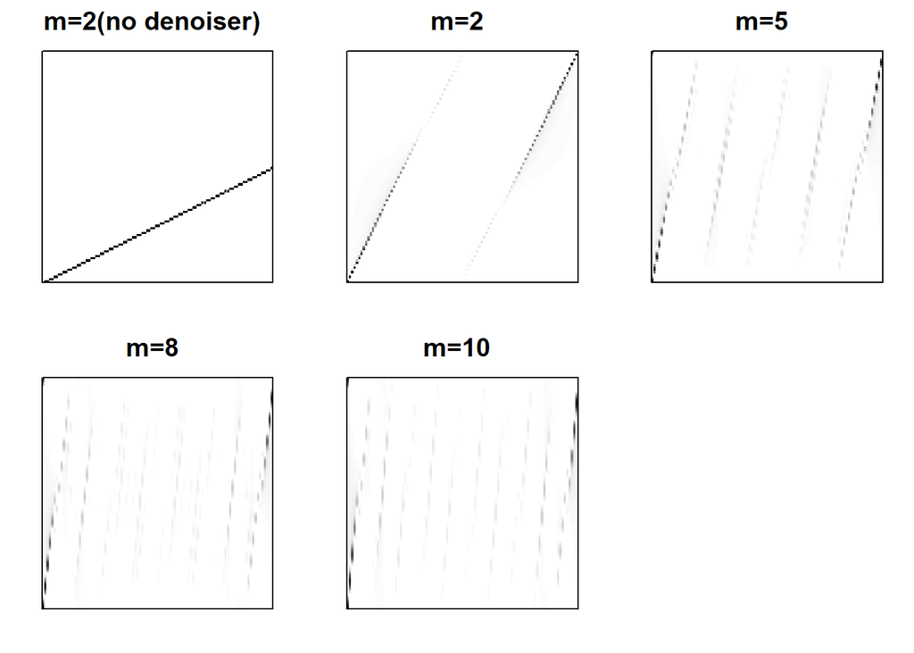

```r
# Строим матрицы с прямыми вида y=x/m

demo_matrices = lapply(c(2, 5, 8, 10), function(m) {matrix(0, ncol=100, nrow=100) |> add.line(a=1/m)})



demo_results <- list(
  "m=2(no denoiser)" = demo_matrices[[1]],
  "m=2" = cssa_denoise(demo_matrices[[1]], num_of_lines = 2, method = "col.col"),
  "m=5" = cssa_denoise(demo_matrices[[2]], num_of_lines = 2, method = "col.col"),
  "m=8" = cssa_denoise(demo_matrices[[3]], num_of_lines = 2, method = "col.col"),
  "m=10" = cssa_denoise(demo_matrices[[4]], num_of_lines = 2, method = "col.col")
)

plot.matrix(
  demo_results,
  from.0.to.1 = TRUE,
  labels = names(demo_results),
  nplots = 3
)
```

*Замечание*: для некоторых алгоритмов помогает увеличить параметр `num.line`. Например, для `col.row` мы можем уменьшить mse таким образом.

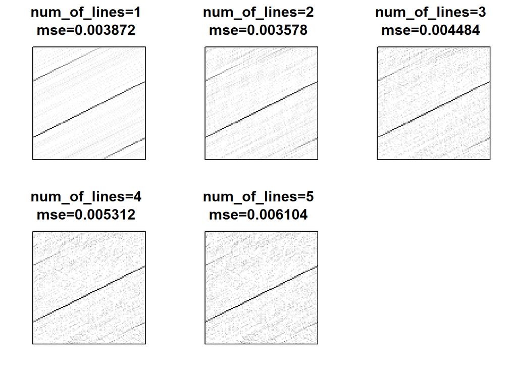

```r
numline_base_matrix <- matrix(0, nrow = 100, ncol = 100) |>
  add.line(a = 0.5, b = 20)

numline_noisy_matrix <- add.noise(numline_base_matrix, sigma = sigma_noise)
numline_grid <- 1:5

numline_results <- lapply(numline_grid, function(k) {
  cssa_denoise(
    numline_noisy_matrix,
    num_of_lines = k,
    method = "col.row"
  )
})

numline_labels <- vapply(seq_along(numline_grid), function(i) {
  cur_mse <- mse(numline_base_matrix, numline_results[[i]])
  sprintf("num_of_lines=%d\nmse=%.6f", numline_grid[i], cur_mse)
}, character(1))

plot.matrix(
  numline_results,
  from.0.to.1 = TRUE,
  labels = numline_labels,
  nplots = 3
)
```

Вернемся к `row.row`. Исключение, когда .col алгоритмы не хуже – одна прямая на диагонали, там все алгоритмы оказываются корректными и col.col работает лучше.

# Hough Transform

```r
source("hough transform/hough_transform.r")
```

## Функции для ошибки параметров HT

```r
convert_ab_to_rho_theta <- function(a, b) {
  theta <- atan2(1, -a)
  rho <- b / sqrt(a^2 + 1)
  if (theta < 0) {
    theta <- theta + pi
    rho <- -rho
  }
  c(rho = rho, theta = theta)
}

find_k_max <- function(acc, k, qrho, qtheta, suppress = FALSE, window = 6) {
  acc_copy <- acc
  maxima <- vector("list", k)

  for (i in seq_len(k)) {
    max_val <- max(acc_copy)
    idx <- which(acc_copy == max_val, arr.ind = TRUE)[1, ]
    maxima[[i]] <- c(rho = qrho[idx[1]], theta = qtheta[idx[2]])

    if (suppress) {
      r_range <- max(1, idx[1] - window):min(nrow(acc_copy), idx[1] + window)
      c_range <- max(1, idx[2] - window):min(ncol(acc_copy), idx[2] + window)
      acc_copy[r_range, c_range] <- 0
    } else {
      acc_copy[idx[1], idx[2]] <- 0
    }
  }

  out <- do.call(rbind, maxima)
  colnames(out) <- c("rho", "theta")
  out
}

compute_err <- function(true, pred) {
  true <- as.matrix(true)
  pred <- as.matrix(pred)

  if (ncol(true) != 2 || ncol(pred) != 2) {
    stop("true and pred must have two columns: rho and theta")
  }

  if (nrow(true) != nrow(pred)) {
    stop("true and pred must have the same number of lines")
  }

  pair_err <- function(tr, tt, pr, pt) {
    pt_alt <- (pt + pi) %% (2 * pi)
    dtheta <- atan2(sin(tt - pt), cos(tt - pt))^2
    dtheta_alt <- atan2(sin(tt - pt_alt), cos(tt - pt_alt))^2

    loss_1 <- (tr - pr)^2 + dtheta
    loss_2 <- (tr + pr)^2 + dtheta_alt

    if (loss_1 <= loss_2) {
      c(dr = (tr - pr)^2, dtheta = dtheta, total = loss_1)
    } else {
      c(dr = (tr + pr)^2, dtheta = dtheta_alt, total = loss_2)
    }
  }

  n_lines <- nrow(true)
  cost <- matrix(0, nrow = n_lines, ncol = n_lines)

  for (i in seq_len(n_lines)) {
    for (j in seq_len(n_lines)) {
      cost[i, j] <- pair_err(
        true[i, 1], true[i, 2],
        pred[j, 1], pred[j, 2]
      )[3]
    }
  }

  if (n_lines == 1) {
    out <- pair_err(true[1, 1], true[1, 2], pred[1, 1], pred[1, 2])
    return(c(dr = unname(out[1]), dtheta = unname(out[2])))
  }

  all_perms <- function(v) {
    if (length(v) == 1) {
      return(matrix(v, nrow = 1))
    }

    out <- lapply(seq_along(v), function(i) {
      rest <- all_perms(v[-i])
      cbind(v[i], rest)
    })
    do.call(rbind, out)
  }

  best_perm <- NULL
  best_cost <- Inf
  perm_mat <- all_perms(seq_len(n_lines))
  for (row_i in seq_len(nrow(perm_mat))) {
    cur_perm <- perm_mat[row_i, ]
    cur_cost <- sum(cost[cbind(seq_len(n_lines), cur_perm)])
    if (cur_cost < best_cost) {
      best_cost <- cur_cost
      best_perm <- cur_perm
    }
  }

  dr_total <- 0
  dtheta_total <- 0
  for (i in seq_len(n_lines)) {
    out <- pair_err(
      true[i, 1], true[i, 2],
      pred[best_perm[i], 1], pred[best_perm[i], 2]
    )
    dr_total <- dr_total + out[1]
    dtheta_total <- dtheta_total + out[2]
  }

  c(dr = unname(dr_total), dtheta = unname(dtheta_total))
}
```

Проверим на корректность

```r
params1 <- matrix(c(1, 2, 8, 9), ncol=2, nrow=2, byrow=T)
params2 <- params1[c(2, 1), ]

cat("Params 1: \n")
```

```
## Params 1:
```

```r
params1
```

```
##      [,1] [,2]
## [1,]    1    2
## [2,]    8    9
```

```r
cat("\nParams 2: \n")
```

```
##
## Params 2:
```

```r
params2
```

```
##      [,1] [,2]
## [1,]    8    9
## [2,]    1    2
```

```r
cat("\nIndicies of 2 maximums: \n")
```

```
##
## Indicies of 2 maximums:
```

```r
qrho = c(1, 2)
qtheta = c(1, 2)
k_maximums <- find_k_max(params1, 2, qrho, qtheta)
k_maximums
```

```
##      rho theta
## [1,]   2     2
## [2,]   2     1
```

```r
cat("\nDifference between params1 and params2\n")
```

```
##
## Difference between params1 and params2
```

```r
compute_err(params1, params2)
```

```
##     dr dtheta
##      0      0
```

## Выборка ошибок HT

```r
methods_ht <- c("row.row", "col.row", "row.col", "col.col")
detectors_ht <- list(
  function(m) cssa_denoise(m, num_of_lines = num_of_lines, method = "row.row"),
  function(m) cssa_denoise(m, num_of_lines = num_of_lines, method = "col.row"),
  function(m) cssa_denoise(m, num_of_lines = num_of_lines, method = "row.col"),
  function(m) cssa_denoise(m, num_of_lines = num_of_lines, method = "col.col")
)

rho_step_ht <- 1
theta_step_ht <- 0.01
n_repeats=16

ht_rows <- vector("list", length = nrow(configs) * n_repeats * length(methods_ht))
ht_idx <- 1L

for (cfg_i in seq_len(nrow(configs))) {
  cfg <- configs[cfg_i, ]
  base_matrix <- make_line_image(
    n_row = cfg$n_row,
    n_col = cfg$n_col,
    a = cfg$a,
    b = cfg$b
  )

  true_line <- matrix(convert_ab_to_rho_theta(cfg$a, cfg$b), nrow = 1)

  for (rep_i in seq_len(n_repeats)) {
    noisy_matrix <- add.noise(base_matrix, sigma = sigma_noise)


    for (method_i in seq_along(methods_ht)) {
      method_name <- methods_ht[method_i]
      detector_fun <- detectors_ht[[method_i]]

      res <- make_accumulator(
        noisy_matrix,
        detector_fun,
        rho_step = rho_step_ht,
        theta_step = theta_step_ht
      )

      pred_plain <- find_k_max(
        res$accumulator,
        k = num_of_lines,
        qrho = res$rho,
        qtheta = res$theta,
        suppress = FALSE,
        window = 0
      )



      err_plain <- compute_err(true_line, pred_plain)

      ht_rows[[ht_idx]] <- data.frame(
        config_id = cfg$config_id,
        description = cfg$description,
        n_col = cfg$n_col,
        n_row = cfg$n_row,
        a = cfg$a,
        b = cfg$b,
        sigma = sigma_noise,
        rep = rep_i,
        method = method_name,
        true_rho = true_line[1, 1],
        true_theta = true_line[1, 2],
        pred_rho = pred_plain[1, 1],
        pred_theta = pred_plain[1, 2],
        dr = as.numeric(err_plain[1]),
        dtheta = as.numeric(err_plain[2]),
        stringsAsFactors = FALSE
      )
      ht_idx <- ht_idx + 1L
    }
  }

}

ht_error_samples <- do.call(rbind, ht_rows)
head(ht_error_samples, 12)
```

```
##           config_id            description n_col n_row a b sigma rep  method
## rho   diag_pos_full Positive full diagonal   100   100 1 0   0.2   1 row.row
## rho1  diag_pos_full Positive full diagonal   100   100 1 0   0.2   1 col.row
## rho2  diag_pos_full Positive full diagonal   100   100 1 0   0.2   1 row.col
## rho3  diag_pos_full Positive full diagonal   100   100 1 0   0.2   1 col.col
## rho4  diag_pos_full Positive full diagonal   100   100 1 0   0.2   2 row.row
## rho5  diag_pos_full Positive full diagonal   100   100 1 0   0.2   2 col.row
## rho6  diag_pos_full Positive full diagonal   100   100 1 0   0.2   2 row.col
## rho7  diag_pos_full Positive full diagonal   100   100 1 0   0.2   2 col.col
## rho8  diag_pos_full Positive full diagonal   100   100 1 0   0.2   3 row.row
## rho9  diag_pos_full Positive full diagonal   100   100 1 0   0.2   3 col.row
## rho10 diag_pos_full Positive full diagonal   100   100 1 0   0.2   3 row.col
## rho11 diag_pos_full Positive full diagonal   100   100 1 0   0.2   3 col.col
##       true_rho true_theta pred_rho pred_theta  dr       dtheta
## rho          0   2.356194        0       2.36   0 0.0000144819
## rho1         0   2.356194        0       2.36   0 0.0000144819
## rho2         0   2.356194        0       2.36   0 0.0000144819
## rho3         0   2.356194        0       2.36   0 0.0000144819
## rho4         0   2.356194        0       2.36   0 0.0000144819
## rho5         0   2.356194        1       2.34   1 0.0002622615
## rho6         0   2.356194        0       2.36   0 0.0000144819
## rho7         0   2.356194        0       2.36   0 0.0000144819
## rho8         0   2.356194        0       2.36   0 0.0000144819
## rho9         0   2.356194        0       2.36   0 0.0000144819
## rho10        0   2.356194       22       2.36 484 0.0000144819
## rho11        0   2.356194        0       2.36   0 0.0000144819
```

## Сводка по ошибкам HT

```r
ht_error_summary <- ht_error_samples |>
  dplyr::group_by(
    config_id, description, n_col, n_row, a, b,
    method
  ) |>
  dplyr::summarise(
    mean_dr = mean(dr),
    median_dr = median(dr),
    mean_dtheta = mean(dtheta),
    median_dtheta = median(dtheta),
    .groups = "drop"
  ) |>
  dplyr::arrange(config_id, mean_dr, mean_dtheta)

ht_error_summary
```

```
## # A tibble: 36 × 11
##    config_id        description n_col n_row     a     b method mean_dr median_dr
##    <chr>            <chr>       <int> <int> <dbl> <dbl> <chr>    <dbl>     <dbl>
##  1 almost_horizont… Almost Hor…   100   100  0.05    30 col.r… 1.44e+1   1.40e-3
##  2 almost_horizont… Almost Hor…   100   100  0.05    30 row.r… 2.59e+1   2.08e+1
##  3 almost_horizont… Almost Hor…   100   100  0.05    30 col.c… 5.29e+2   2.43e+2
##  4 almost_horizont… Almost Hor…   100   100  0.05    30 row.c… 1.05e+3   8.98e+2
##  5 diag_neg_full    Negative f…   100   100 -1      101 row.r… 2.36e-1   1.75e-1
##  6 diag_neg_full    Negative f…   100   100 -1      101 col.r… 1.78e+1   7.09e+0
##  7 diag_neg_full    Negative f…   100   100 -1      101 row.c… 4.09e+1   6.67e+0
##  8 diag_neg_full    Negative f…   100   100 -1      101 col.c… 2.61e+3   2.76e+3
##  9 diag_pos_full    Positive f…   100   100  1        0 col.c… 0         0
## 10 diag_pos_full    Positive f…   100   100  1        0 row.r… 0         0
## # ℹ 26 more rows
## # ℹ 2 more variables: mean_dtheta <dbl>, median_dtheta <dbl>
```

## Матрица средних ошибок HT

```r
dr <- xtabs(mean_dr ~ config_id + method, data = ht_error_summary)
dr
```

```
##                    method
## config_id                col.col      col.row      row.col      row.row
##   almost_horizontal 5.291725e+02 1.444693e+01 1.051937e+03 2.585698e+01
##   diag_neg_full     2.607436e+03 1.783205e+01 4.090567e+01 2.362055e-01
##   diag_pos_full     0.000000e+00 4.118750e+01 5.250000e+01 0.000000e+00
##   horizontal        1.853937e+03 9.676250e+02 1.856312e+03 6.250000e-02
##   shallow_bottom    1.890687e+03 0.000000e+00 1.766937e+03 0.000000e+00
##   shallow_center    1.019696e+03 3.564853e-01 1.080168e+03 5.829664e+02
##   short_corner      6.982885e+02 2.092271e+03 1.006383e+03 4.217636e+02
##   steep_full        3.118925e+03 3.108356e+02 1.141051e+03 1.532629e+03
##   steep_shifted     1.815631e+03 1.068151e+00 6.569909e+02 1.242248e-02
```

Нормировка

```r
dr_norm <- t(apply(dr, 1, function(x) {
  row_min <- min(x)
  if (row_min == 0) {
    ifelse(x == 0, 1, Inf)
  } else {
    x / row_min
  }
}))
dr_norm
```

```
##                    method
## config_id                col.col      col.row      row.col     row.row
##   almost_horizontal     36.62871     1.000000    72.813837    1.789791
##   diag_neg_full      11038.84429    75.493791   173.178269    1.000000
##   diag_pos_full          1.00000          Inf          Inf    1.000000
##   horizontal         29663.00000 15482.000000 29701.000000    1.000000
##   shallow_bottom             Inf     1.000000          Inf    1.000000
##   shallow_center      2860.41652     1.000000  3030.048510 1635.317047
##   short_corner           1.65564     4.960766     2.386130    1.000000
##   steep_full            10.03400     1.000000     3.670914    4.930673
##   steep_shifted     146156.92369    85.985292 52887.260751    1.000000
```

Аналогично для $\Delta\theta$:

```r
dt <- xtabs(mean_dtheta ~ config_id + method, data = ht_error_summary)
dt
```

```
##                    method
## config_id                col.col      col.row      row.col      row.row
##   almost_horizontal 2.626952e+00 5.876203e-06 1.910483e+00 8.940193e-03
##   diag_neg_full     6.177028e-01 1.011539e-04 5.371608e-04 4.866542e-05
##   diag_pos_full     1.448190e-05 7.941303e-05 3.295436e-05 1.448190e-05
##   horizontal        2.492095e+00 6.566405e-01 1.483508e+00 7.879545e-06
##   shallow_bottom    1.106902e+00 1.974857e-05 7.288658e-01 1.974857e-05
##   shallow_center    4.137971e+00 2.183381e-05 1.109970e+00 1.042723e-01
##   short_corner      5.557401e+00 3.066314e+00 3.576404e+00 6.396331e-01
##   steep_full        9.229030e-01 1.049920e-04 4.414880e+00 2.060641e+00
##   steep_shifted     2.131103e-01 4.222842e-06 2.338521e+00 4.222842e-06
```

```r
dt_norm <- sweep(dt, 1, apply(dt, 1, min), "/")
dt_norm
```

```
##                    method
## config_id                col.col      col.row      row.col      row.row
##   almost_horizontal 4.470492e+05 1.000000e+00 3.251221e+05 1.521424e+03
##   diag_neg_full     1.269285e+04 2.078559e+00 1.103783e+01 1.000000e+00
##   diag_pos_full     1.000000e+00 5.483604e+00 2.275554e+00 1.000000e+00
##   horizontal        3.162739e+05 8.333483e+04 1.882733e+05 1.000000e+00
##   shallow_bottom    5.604976e+04 1.000000e+00 3.690728e+04 1.000000e+00
##   shallow_center    1.895213e+05 1.000000e+00 5.083721e+04 4.775728e+03
##   short_corner      8.688420e+00 4.793864e+00 5.591336e+00 1.000000e+00
##   steep_full        8.790223e+03 1.000000e+00 4.204969e+04 1.962665e+04
##   steep_shifted     5.046610e+04 1.000000e+00 5.537791e+05 1.000000e+00
```

Возможно, с увеличением размера выборки, результат изменится. Пока наблюдается доминирование `row.row`. Заметим, что на изображении с прямой $y=2x-1$ (steep_full) наблюдаются аномально высокие значения отклонения `row.row`, хотя при такой конфигурации сигнал попадает на каждую строку матрицы.